# Datenauswertung HypoMind-23

Clara Brendler, Josephine Heinecke und Cara Pociuli

2024-01-26

# 1 Vorbereitung

```r
library(psych)
library(ez)
```

```r
library(ggplot2)
library(lsr)
library(dplyr)
library(reshape2)
Warnings = FALSE
```

```r
setwd("C:/Users/spoci/OneDrive/Desktop/ExPrak_DA/ExPrak_DA")
```

Daten einlesen

```r
dat <- read.csv("hypomind-23_data.csv")
```

# 2 Daten prüfen

Bei der visuellen Inspektion der Daten fiel auf, dass zwei Proband:innen (Zeile 31 und 34) 0 Mal ein gutes Decks gewählt haben. Die zwei Datensätze wurden einzeln angeschaut: die zwei Proband:innen gehören beide der Zeitdruck-Bedingung (TP) an und haben in keinem Trial ein Deck gewählt. Die beiden Proband:innen werden von der Datenauswertung ausgeschlossen (s. Exclusions in Prä-Registrierung).

```r
dat <- dat[-c(31, 34), ]
```

# 3 Zuordnung der Proband:innen zu Gruppen (HPS)

Wir teilen die Proband:innen anhand der HPS-Scores in drei gleichgroße Gruppen. Probandinnen im unteren vs. oberen Terzil bleiben für die Datenauswertung. Proband:innen im mittleren Drittel werden aus der Datenauswertung ausgeschlossen.

Bestimmen der relevanten Quantile der HPS-Verteilung

```r
cutoff <- quantile(dat$hps_sum, c(0:3/3))
dat$hps_group <- with(dat, cut(hps_sum, cutoff, include.lowest = T, labels = c('low','mid','high')))
```

Kopie von Datensatz

```r
d <- dat
```

nur die Proband:innen mit ‘low’ und ‘high’ in der group-Variable

```r
d <- d[d$hps_group != 'mid',]
```

N = 49, n_low = 17, n_mid = 16, n_high = 16

# 4 Übersicht über Bedingungen

nTP = condition 1: IGT without time pressure; TP = condition 2: IGT with time pressure; high = above cut-off (individuals with higher hypomanic scores); low = below cut-off (individuals with lower hypomanic scores)

```r
nTP_low <- d[d$group == "nTP" & d$hps_group == "low", ]
nTP_high <- d[d$group == "nTP" & d$hps_group == "high", ]
TP_low <- d[d$group == "TP" & d$hps_group == "low", ]
TP_high <- d[d$group == "TP" & d$hps_group == "high", ]
```

# 5 Deskriptive Statistiken

## 5.1 HPS

Über alle Proband:innen hinweg

### 5.1.1 Mittelwert

```r
MW_HPS <- round(mean(dat$hps_sum), 3)
MW_HPS
```

```
## [1] 17.122
```

### 5.1.2 Standardabweichung

```r
Sd_HPS <- round(sd(dat$hps_sum), 3)
Sd_HPS
```

```
## [1] 8.087
```

### 5.1.3 Alter der Proband:innen

```r
MW_age <- round(mean(dat$age), 3)
MW_age
```

```
## [1] 30.612
```

```r
range_age <- range(dat$age)
range_age
```

```
## [1] 18 66
```

### 5.1.4 Geschlecht der Proband:innen

1: w, 2: m, 3: d

```r
s <- table(dat$sex)
prozentsatz_w <- (s[1]/sum(s))*100
prozentsatz_m <- (s[2]/sum(s))*100
prozentsatz_d <- (s[3]/sum(s))*100
rbind(prozentsatz_w, prozentsatz_m, prozentsatz_d)
```

```
##                       1
## prozentsatz_w 59.183673
## prozentsatz_m 38.775510
## prozentsatz_d  2.040816
```

### 5.1.5 1 Histogramm Verteilung HPS Scores Proband:innen

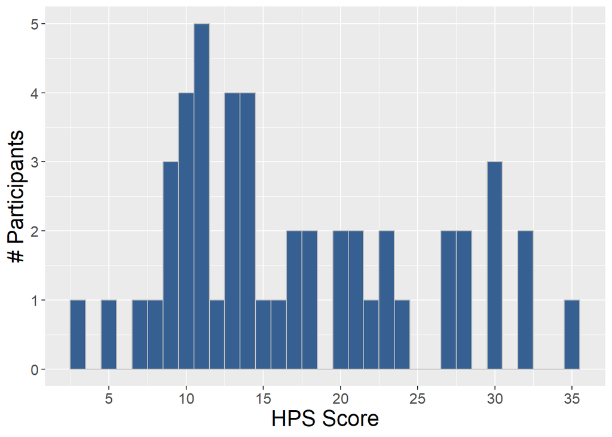

```r
ggplot(data = dat,
       aes(x = hps_sum)) +
  geom_histogram(binwidth = 1,
                 fill = "#376092",
                 col = "grey") +
  xlab("HPS Score") +
  ylab("# Participants") +
  scale_x_continuous(breaks = seq(min(0), max(48), by = 5)) +
theme(text = element_text(size = 10),
      title = element_text(size = 18),
      axis.text = element_text(size = 12))
```

### 5.1.6 2 Grafik Verteilung HPS Scores Proband:innen

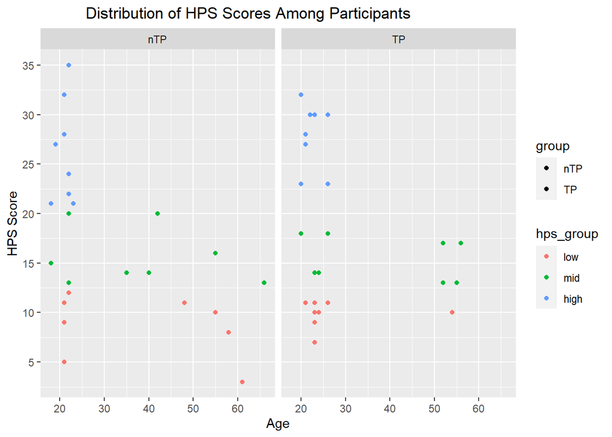

```r
ggplot(data = dat,
       aes(x = age,
           y = hps_sum, color = hps_group, group = hps_group, fill = group)
       ) +
  ggtitle("Distribution of HPS Scores Among Participants") +
  geom_point() +
  xlab("Age") +
  ylab("HPS Score") +
  scale_y_continuous(breaks = seq(min(0), max(48), by = 5)) +
  facet_grid(. ~ group) +
  theme(plot.title = element_text(hjust = 0.3))
```

### 5.1.7 1 und 2 zusammengefügt zu einer Grafik

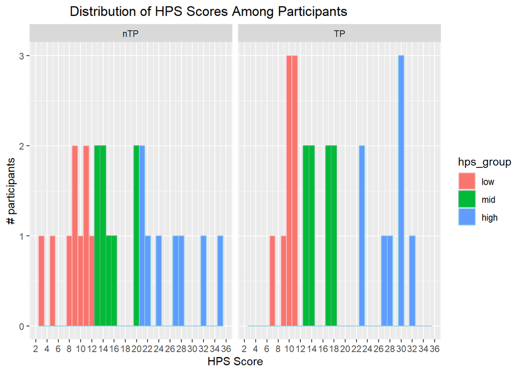

```r
ggplot(data = dat,
       aes(x = hps_sum, color = hps_group, group = hps_group, fill = hps_group)
       ) +
  geom_histogram(binwidth = 1) +
  scale_color_manual(values = c("low"="pink", "mid"="#49b675", "high"="skyblue")) +
  ggtitle("Distribution of HPS Scores Among Participants") +
  xlab("HPS Score") +
  ylab("# participants") +
  facet_grid(. ~ group) +
  scale_x_continuous(breaks = seq(min(0), max(48), by = 2)) +
  theme(plot.title = element_text(hjust = 0.3))
```

## 5.2 Leistung im IGT

Unterscheidung in Gruppen: Proband:innen mit niedriger, mittlerer oder hoher hypomaner Persönlichkeitsausprägung

### 5.2.1 Mittelwerte

```r
nTP_mid <- dat[dat$group == "nTP" & dat$hps_group == "mid", ]
TP_mid <- dat[dat$group == "TP" & dat$hps_group == "mid", ]
```

```r
MW_nTP_low <- mean(nTP_low$sum_good_deck)
MW_nTP_high <- mean(nTP_high$sum_good_deck)
MW_TP_low <- mean(TP_low$sum_good_deck)
MW_TP_high <- mean(TP_high$sum_good_deck)
MW_nTP_mid <- mean(nTP_mid$sum_good_deck)
MW_TP_mid <- mean(TP_mid$sum_good_deck)
rbind(MW_nTP_low, MW_nTP_high, MW_TP_low, MW_TP_high, MW_nTP_mid, MW_TP_mid)
```

```
##                 [,1]
## MW_nTP_low  23.66667
## MW_nTP_high 25.00000
## MW_TP_low   23.75000
## MW_TP_high  23.87500
## MW_nTP_mid  21.62500
## MW_TP_mid   13.25000
```

50 Trials -> betrachtet man die für die Hypothesentestung relevanten HPS-Gruppen low und high, so wurden bei etwa 50% der Trials gute Stapel gewählt und bei etwa 50% der Trials schlechte Stapel Frage: Haben die Proband:innen die Aufgabe beim IGT richtig verstanden? Ziel war den Gesamtgewinn zu maximieren, indem die guten Stapel gewählt werden (besseres Netto-Ergebnis). Es wurde von den meisten Proband:innen nicht häufiger der gute Stapel gewählt. -> Manipulation guter Stapel vs. schlechter Stapel hat nicht wirklich funktioniert (Warum? Systematik nicht herausgefunden (Verhalten der Proband:innen deutet darauf hin, dass nicht verstanden wurde, welches die guten Stapel sind)? Nach Herausfinden Strategiewechsel? Aufgabe zu schwierig? Zu wenig Durchgänge für Verstehen in unserem Experiment?).

### 5.2.2 Standardabweichung

```r
Sd_nTP_low <- sd(nTP_low$sum_good_deck)
Sd_nTP_high <- sd(nTP_high$sum_good_deck)
Sd_TP_low <- sd(TP_low$sum_good_deck)
Sd_TP_high <- sd(TP_high$sum_good_deck)
Sd_nTP_mid <- sd(nTP_mid$sum_good_deck)
Sd_TP_mid <- sd(TP_mid$sum_good_deck)
rbind(Sd_nTP_low, Sd_nTP_high, Sd_TP_low, Sd_TP_high, Sd_nTP_mid, Sd_TP_mid)
```

```
##                 [,1]
## Sd_nTP_low  9.886860
## Sd_nTP_high 5.154748
## Sd_TP_low   4.026697
## Sd_TP_high  6.266407
## Sd_nTP_mid  7.558108
## Sd_TP_mid   5.946187
```

### 5.2.3 Range und Variationsbreite

```r
Range_nTP_low <- range(nTP_low$sum_good_deck)
Range_nTP_high <- range(nTP_high$sum_good_deck)
Range_TP_low <- range(TP_low$sum_good_deck)
Range_TP_high <- range(TP_high$sum_good_deck)
Range_nTP_mid <- range(nTP_mid$sum_good_deck)
Range_TP_mid <- range(TP_mid$sum_good_deck)
rbind(Range_nTP_low, Range_nTP_high, Range_TP_low, Range_TP_high, Range_nTP_mid, Range_TP_mid)
```

```
##                [,1] [,2]
## Range_nTP_low     4   39
## Range_nTP_high   18   35
## Range_TP_low     19   31
## Range_TP_high    16   36
## Range_nTP_mid    13   34
## Range_TP_mid      2   21
```

```r
Variationsbreite_nTP_low <- diff(range(nTP_low$sum_good_deck))
Variationsbreite_nTP_high <- diff(range(nTP_high$sum_good_deck))
Variationsbreite_TP_low <- diff(range(TP_low$sum_good_deck))
Variationsbreite_TP_high <- diff(range(TP_high$sum_good_deck))
Variationsbreite_nTP_mid <- diff(range(nTP_mid$sum_good_deck))
Variationsbreite_TP_mid <- diff(range(TP_mid$sum_good_deck))
rbind(Variationsbreite_nTP_low, Variationsbreite_nTP_high, Variationsbreite_TP_low, Variationsbreite_TP_high, Variationsbreite_nTP_mid, Variationsbreite_TP_mid)
```

```
##                           [,1]
## Variationsbreite_nTP_low    35
## Variationsbreite_nTP_high   17
## Variationsbreite_TP_low     12
## Variationsbreite_TP_high    20
## Variationsbreite_nTP_mid    21
## Variationsbreite_TP_mid     19
```

### 5.2.4 Grafik Verteilung IGT Leistung Proband:innen - HPS Scores

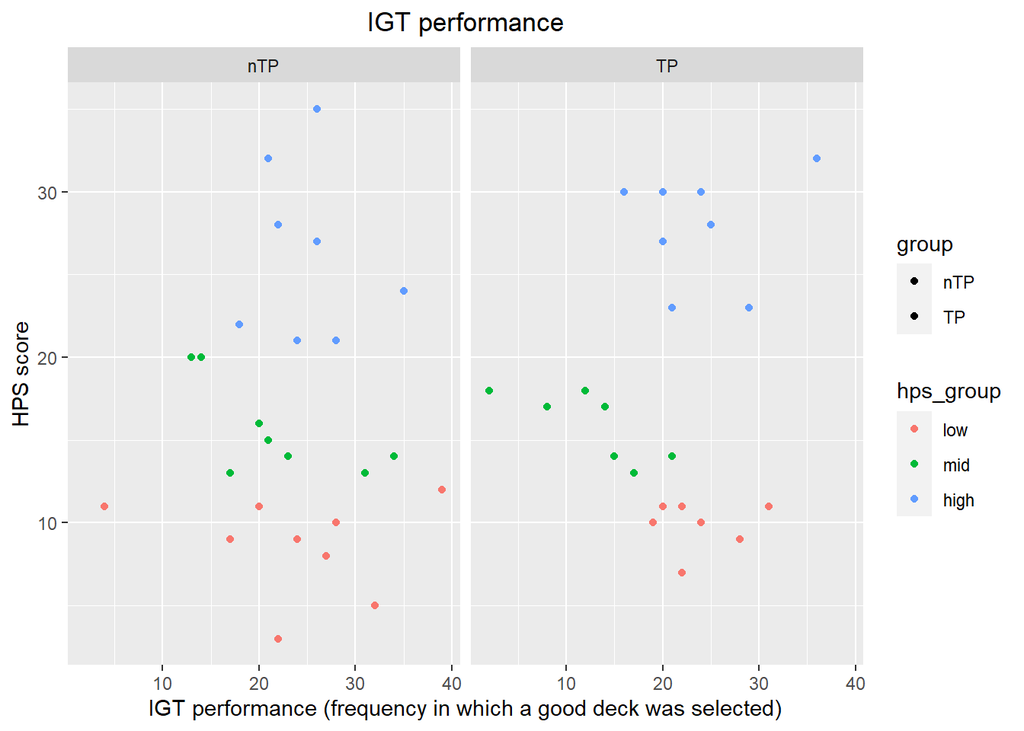

```r
ggplot(data = dat,
       aes(x = sum_good_deck,
           y = hps_sum, color = hps_group, group = hps_group, fill = group)
       ) +
  ggtitle("IGT performance") +
  geom_point() +
  xlab("IGT performance (frequency in which a good deck was selected)") +
  ylab("HPS score") +
  facet_grid(. ~ group) +
  theme(plot.title = element_text(hjust = 0.5))
```

### 5.2.5 Violinplots “Wahl des gewinnbringenden Stapels”

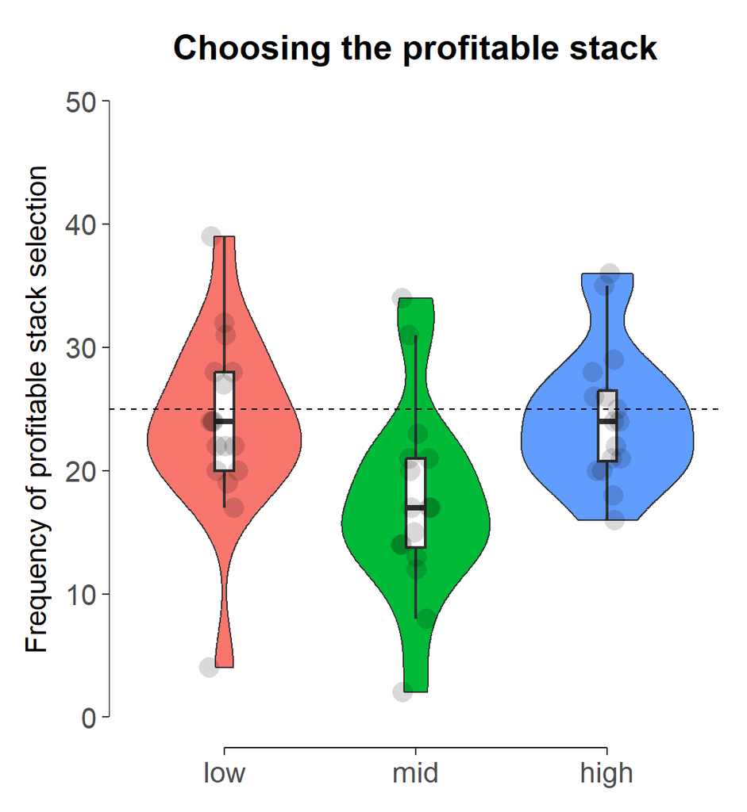

```r
choicePlot <- ggplot(dat, aes(x = hps_group, fill = hps_group, y = sum_good_deck )) +
    geom_violin(lwd = 0.25) +
    geom_boxplot(width=0.1, fill="white", outlier.shape = NA) +
    geom_point(alpha= 0.15, size = 3, shape = 16, position = position_jitterdodge(), show.legend = FALSE) +
    ggtitle('Choosing the profitable stack') +
    ylab('Frequency of profitable stack selection') +
    scale_y_continuous(limits = c(0,50), breaks = seq(0,50,10)) +
    geom_segment(aes(x=min(as.numeric(hps_group)),xend=max(as.numeric(hps_group)),y=-Inf,yend=-Inf), colour = "black", size = 0.25) +
    geom_segment(aes(y=0,yend=50,x=-Inf,xend=-Inf), colour = "black", size = 0.25) +
    geom_hline(yintercept = 25, linetype = 'dashed', color = 'black', size = 0.25) +
    theme_bw(base_size=10) +
    theme(panel.grid = element_blank(),
          panel.border = element_blank(),
          plot.title = element_text(size = 12, face = "bold", hjust = 0.5, vjust = -0.5),
          axis.text.x = element_text(size = 10 ),  # rotate x-axis labels so they don't overlap,
          axis.text.y = element_text(size = 10),
          axis.title.x = element_blank(),
          axis.title.y = element_text(size = 10, hjust = 0.5, angle = 90, margin = margin(t = 0, r = 5, b = 0, l = 0)),
          legend.position = 'none',
          axis.ticks = element_line(size = 0.25),
          plot.margin = unit(c(3, 3, 3, 3), "mm"))
ggsave('plot.choices.png', choicePlot, width = 3.63, height = 3.95, dpi = 300)
knitr::include_graphics("plot.choices.png")
```

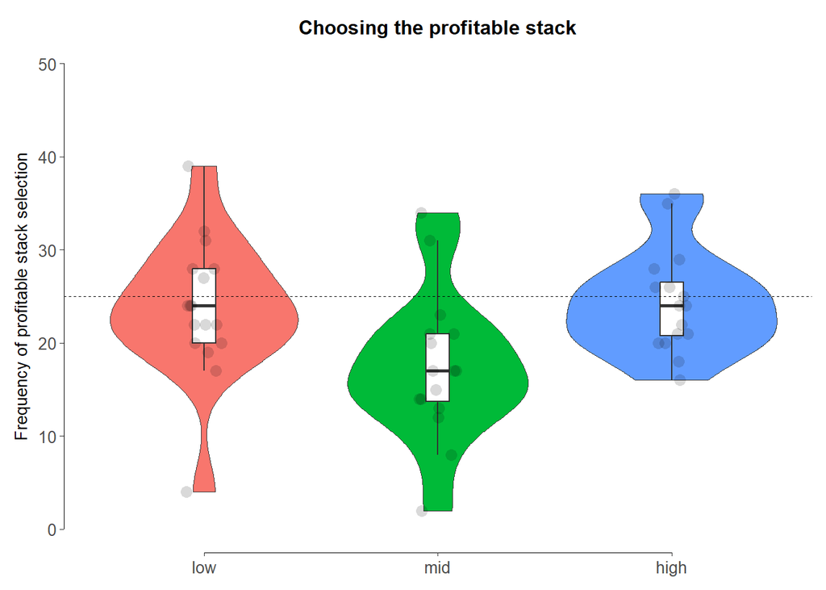

```r
choicePlot
```

# 6 Hypothese 1

## 6.1 Einfaktorielle ANOVA

### 6.1.1 Vorbereitung

Do individuals with higher hypomanic scores exhibit riskier decision-making patterns and, consequently, select the advantageous decks on the IGT less frequently as compared to those with lower hypomanic scores?

Abhängige Variable: Anzahl gute Decks (sum_good_deck) Unabhängige Variable: HPS-Gruppe low / high

p (Anzahl Faktorstufen) = 2 N = 33

```r
table(d$group, d$hps_group)
```

```
##
##       low mid high
##   nTP   9   0    8
##   TP    8   0    8
```

n = 17 (low) n = 16 (high) -> unbalanciertes Design

H0: u high >= u low H1: u high < u low

UV (hohe vs. niedrige hypomane Persönlichkeitsausprägung) als Faktor definieren

```r
d$hps_group <- factor(d$hps_group, levels = c("low", "high"))
```

Faktorstufen anzeigen lassen

```r
levels(d$hps_group)
```

```
## [1] "low"  "high"
```

### 6.1.2 Berechnung einfaktorielle ANOVA

alpha = 0.05

```r
anova1_resultat <- aov(sum_good_deck ~ hps_group, data = d)
# ezANOVA1_resultat <- ezANOVA(data = d, wid = ID, dv = sum_good_deck, between = hps_group, type = 3)
```

### 6.1.3 Ergebnisse einfaktorielle ANOVA

```r
summary(anova1_resultat)
```

```
##             Df Sum Sq Mean Sq F value Pr(>F)
## hps_group    1    4.4    4.41     0.1  0.753
## Residuals   31 1361.5   43.92
```

Der empirische F-Wert ist kleiner als der für das 5%-Niveau kritische F-Wert und damit nicht signifikant. Es ist davon auszugehen, dass die Nullhypothese “Die IGT-Leistung der Proband:innen mit hoher hypomaner Persönlichkeitsausprägung im Vergleich zur IGT-Leistung der Proband:innen mit niedriger Persönlichkeitsausprägung ist besser oder gleich.” beizubehalten ist.

```r
eta_squared_anova1 <- etaSquared(anova1_resultat)
eta_squared_anova1
```

```
##                eta.sq eta.sq.part
## hps_group 0.003230064 0.003230064
```

Durch die HPS-Gruppen low und high wird nahezu keine Varianz aufgeklärt.

## 6.2 Korrelation “hypomanic traits” und “decision-making performance on the IGT”

über alle Proband:innen (n=49), mehr Leute -> größere Power

```r
cor.test(dat$hps_sum, dat$sum_good_deck)
```

```
##
##  Pearson's product-moment correlation
##
## data:  dat$hps_sum and dat$sum_good_deck
## t = 0.15966, df = 47, p-value = 0.8738
## alternative hypothesis: true correlation is not equal to 0
## 95 percent confidence interval:
##  -0.2596141  0.3024983
## sample estimates:
##        cor
## 0.02328215
```

r = 0.02328215 p-value = 0.8738 > 0.05 Keine signifikante lineare Korrelation zwischen den Variablen hps_sum und sum_good_deck

Streudiagramm 1

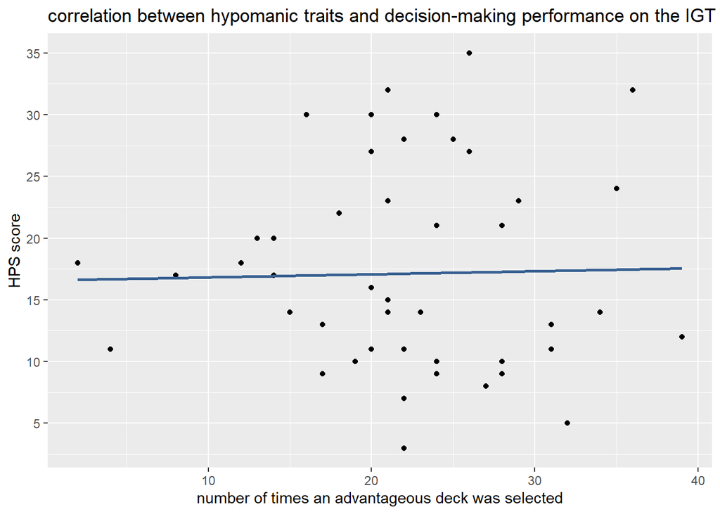

```r
ggplot(data = dat,
       aes(x = sum_good_deck,
           y = hps_sum)
       ) +
  ggtitle("correlation between hypomanic traits and decision-making performance on the IGT") +
  geom_point() +
  geom_smooth(method = "lm", se = FALSE, color = "#376092") +
  scale_y_continuous(breaks = seq(min(0), max(48), by = 5)) +
  xlab("number of times an advantageous deck was selected") +
  ylab("HPS score")
```

Streudiagramm 2

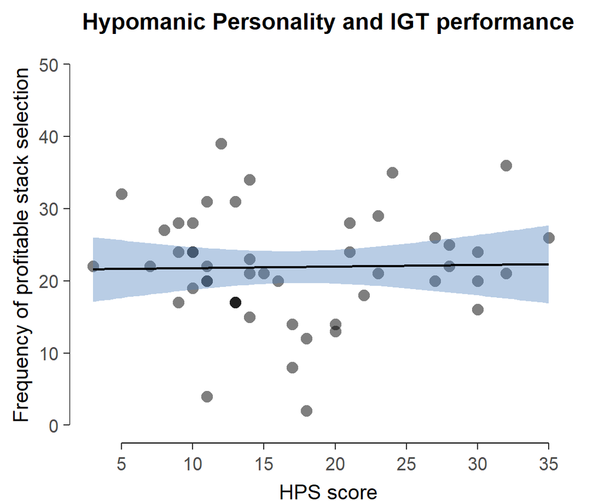

```r
corrPlot = ggplot(dat, aes(x = hps_sum, y = sum_good_deck)) +
  ggtitle("Hypomanic Personality and IGT performance") +
  #geom_point(aes(color = factor(group, levels = c('high','low','mid'))), alpha = 1, size = 2, shape = 16, show.legend = FALSE) +
  geom_point(alpha = 0.5, size = 2, shape = 16, show.legend = FALSE) +
  geom_smooth(method='lm', formula = y~x, color = 'black', size = 0.5, fill = '#4F81BD') +
  scale_x_continuous(limits = c(3,36), breaks = seq(5,35,5), name = "HPS score") +
  scale_y_continuous(limits = c(0,50), breaks = seq(0,50,10), name = "Frequency of profitable stack selection") +
  geom_segment(aes(x=5,xend=35,y=-Inf,yend=-Inf), colour = "black", size = 0.25) +
  geom_segment(aes(y=0,yend=50,x=-Inf,xend=-Inf), colour = "black", size = 0.25) +
  theme_bw() +
  theme(plot.margin=margin(5.5,5.5,-1,5.5),
        plot.title = element_text(hjust = 0.5, size = 10, face = 'bold'),
        legend.title = element_text(size = 9),
        axis.title = element_text(size = 8),
        axis.title.x = element_text(size = 9, margin = margin(t = 5, r = 0, b = 0, l = 0)),
        axis.title.y = element_text(size=9,margin = margin(t = 0, r = 3, b = 0, l = 0)),
        axis.text.x = element_text(size=8, angle = 0, hjust=0.5, vjust=0.5),
        axis.text.y = element_text(size=8),
        panel.grid.major = element_blank(),
        panel.grid.minor = element_blank(),
        panel.border = element_blank(),# element_rect(size = 0.25),
        line = element_line(size=0.25))
ggsave('plot.correlation.png', corrPlot, width = 3.65, height = 3.05, dpi = 300)
knitr::include_graphics("plot.correlation.png")
```

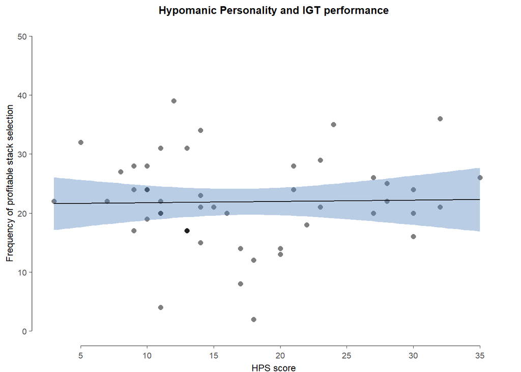

```r
corrPlot
```

–> Ergebnis Testung Hypothese 1: Kein Unterschied zwischen hypoman und nicht-hypoman

# 7 Hypothese 2

## 7.1 Zweifaktorielle ANOVA

### 7.1.1 Vorbereitung

Variablen group, hps_group und ID als Faktoren definieren

```r
d$group <- as.factor(d$group)
d$ID <- as.factor(d$ID)
```

Überprüfen, ob Design balanciert oder unbalanciert ist

```r
table(d$group, d$hps_group)
```

```
##
##       low high
##   nTP   9    8
##   TP    8    8
```

-> Unbalanciertes Design

### 7.1.2 Berechnung zweifaktorielle ANOVA

abhängige Variable: Anzahl an guten Decks (sum_good_deck) Faktoren: Bedingung nTP, TP; HPS-Gruppe low, high

```r
anova2_resultat <- ezANOVA(
  data = d,
  dv = sum_good_deck,
  wid = ID,
  between = c(group, hps_group),
  type = 3,  # ANOVA Typ III weil unbalanciertes Design und Reihenfolge der Faktoren egal
)
```

```
## Coefficient covariances computed by hccm()
```

### 7.1.3 Zweifaktorielle ANOVA-Ergebnisse

```r
print(anova2_resultat)
```

```
## $ANOVA
##            Effect DFn DFd          F         p p<.05         ges
## 2           group   1  29 0.04772437 0.8286015       0.001642964
## 3       hps_group   1  29 0.09353977 0.7619092       0.003215139
## 4 group:hps_group   1  29 0.06421791 0.8017374       0.002209518
##
## $`Levene's Test for Homogeneity of Variance`
##   DFn DFd      SSn     SSd        F         p p<.05
## 1   3  29 77.95833 580.375 1.298466 0.2937445
```

F-Werte nicht signifikant, Eta-Quadrat (ges): es wird nahezu keine Varianz aufgeklärt

Interaktionsplots:

Haupteffekt Faktor A (nTP, TP);

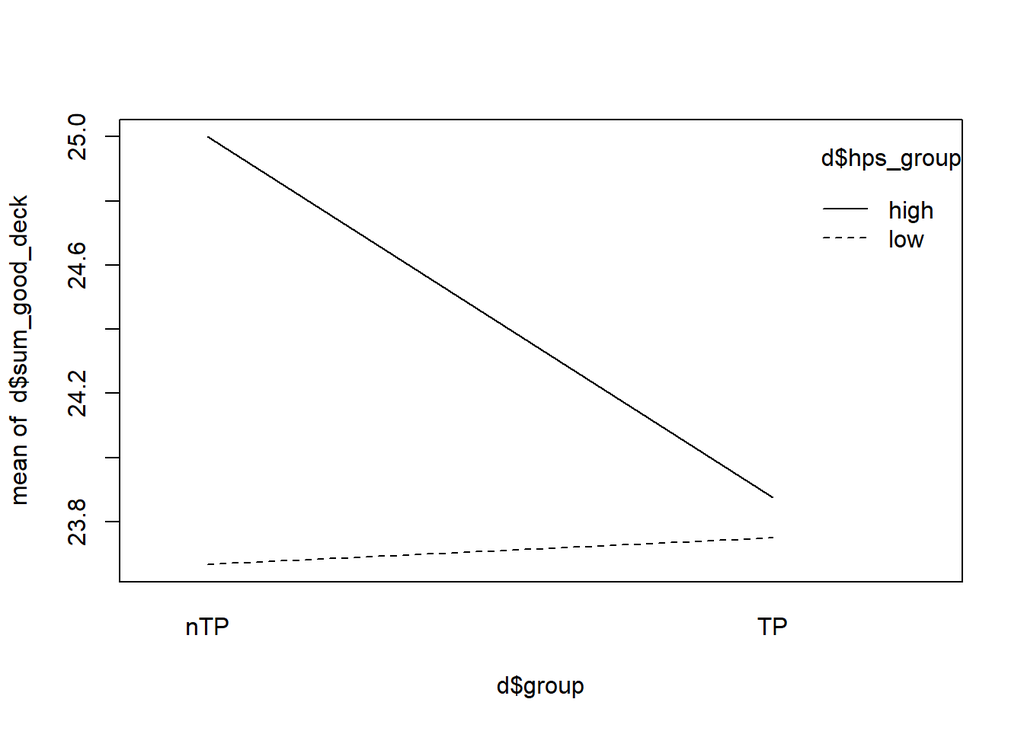

```r
interaction.plot(d$group, d$hps_group, d$sum_good_deck)
```

Frage: Sind Linien signifikant voneinander verschieden? Standardfehler anschauen, & KI in Plot einfügen, um Überlappung der Werte zu sehen (Erwartung starke Überlappung)

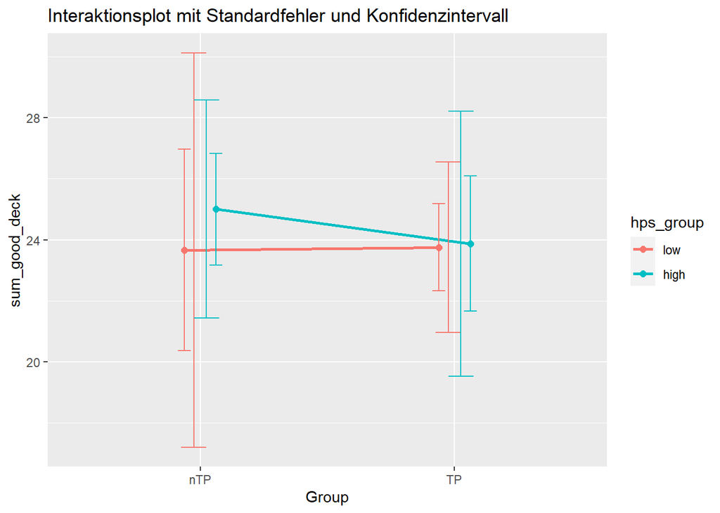

```r
plot_data <- aggregate(sum_good_deck ~ group + hps_group, data = d, mean)
se <- aggregate(sum_good_deck ~ group + hps_group, data = d, function(x) sd(x) / sqrt(length(x)))
ci <- aggregate(sum_good_deck ~ group + hps_group, data = d, function(x) 1.96 * sd(x) / sqrt(length(x)))

ggplot(plot_data, aes(x = group, y = sum_good_deck, color = hps_group, group = hps_group)) +
  geom_line(position = position_dodge(0.25), size = 1) +
  geom_point(position = position_dodge(0.25), size = 2, shape = 16) +
  geom_errorbar(aes(ymin = sum_good_deck - ci$sum_good_deck,
      ymax = sum_good_deck + ci$sum_good_deck),
      position = position_dodge(0.1),
      width = 0.2) +
  geom_errorbar(aes(ymin = sum_good_deck - se$sum_good_deck, ymax = sum_good_deck + se$sum_good_deck), position = position_dodge(0.25), width = 0.1) +
  xlab("Group") +
  ylab("sum_good_deck") +
  ggtitle("Interaktionsplot mit Standardfehler und Konfidenzintervall")
```

-> Kein signifikanter Unterschied, kein Haupteffekt interpretierbar

Haupteffekt von Faktor B (low, high)

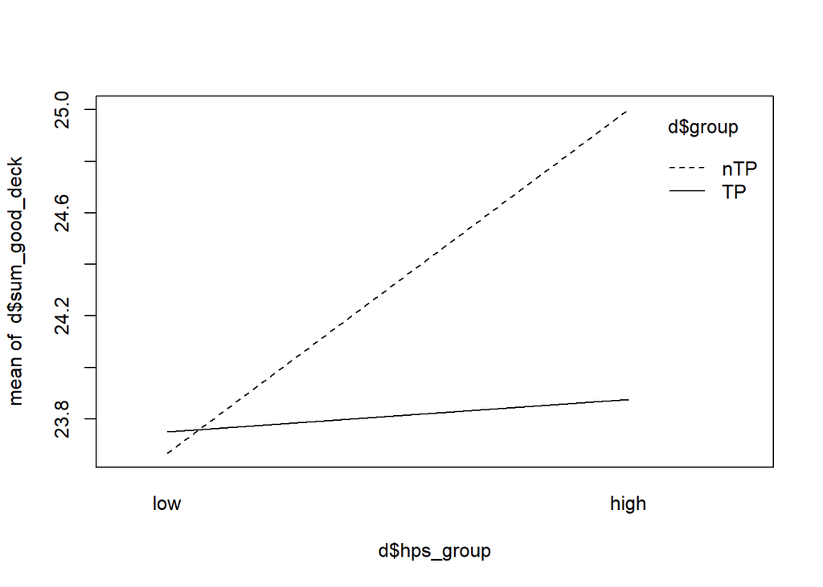

```r
interaction.plot(d$hps_group, d$group, d$sum_good_deck)
```

-> Kein Haupteffekt für Faktor B interpretierbar

Make Boxplots

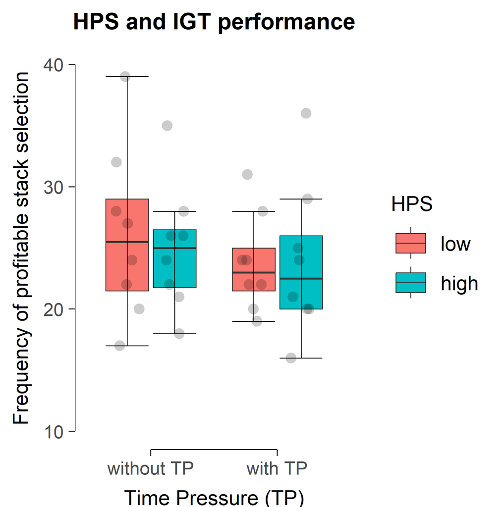

```r
d$hps_group_recode = 'HPS-'
d$hps_group_recode[d$hps_group == 'high'] = 'HPS+'
d$HPSxTP = paste(d$hps_group_recode,d$group)

library(ggplot2)
boxpl <- ggplot(d, aes(x = group, fill = hps_group, y = sum_good_deck)) +
  ggtitle("HPS and IGT performance") +
  geom_boxplot(alpha = 1, outlier.shape = NA, lwd = 0.2) +
  stat_boxplot(geom = "errorbar", width = 0.75, lwd = 0.2) +
  geom_point(alpha= 0.2, size = 2, shape = 16, position = position_jitterdodge(), show.legend = FALSE) +
  scale_x_discrete(name = "Time Pressure (TP)", labels = c('without TP', 'with TP')) +
  scale_y_continuous(limits = c(10,40), breaks = seq(10,40,10), name = "Frequency of profitable stack selection") +
  geom_segment(aes(x=min(as.numeric(factor(group))),xend=max(as.numeric(factor(group))),y=-Inf,yend=-Inf), colour = "black", size = 0.25) +
  geom_segment(aes(y=10,yend=40,x=-Inf,xend=-Inf), colour = "black", size = 0.25) +
  guides(fill=guide_legend("HPS")) +
  theme_bw() +
  theme(plot.margin=margin(5.5,5.5,-1,5.5),
        plot.title = element_text(hjust = 0.5, size = 10, face = 'bold'),
        legend.title = element_text(size = 9),
        axis.title = element_text(size = 8),
        axis.title.x = element_text(size = 9, margin = margin(t = 5, r = 0, b = 0, l = 0)),
        axis.title.y = element_text(size=9,margin = margin(t = 0, r = 5, b = 0, l = 0)),
        axis.text.x = element_text(size=8, angle = 0, hjust=0.5, vjust=1),
        axis.text.y = element_text(size=8),
        panel.grid.major = element_blank(),
        panel.grid.minor = element_blank(),
        panel.border = element_blank(), #element_rect(size = 0.25),
        line = element_line(size=0.25))
ggsave('plot.boxplots.png', boxpl, width = 3.06, height = 3.08, dpi = 600)
knitr::include_graphics("plot.boxplots.png")
```

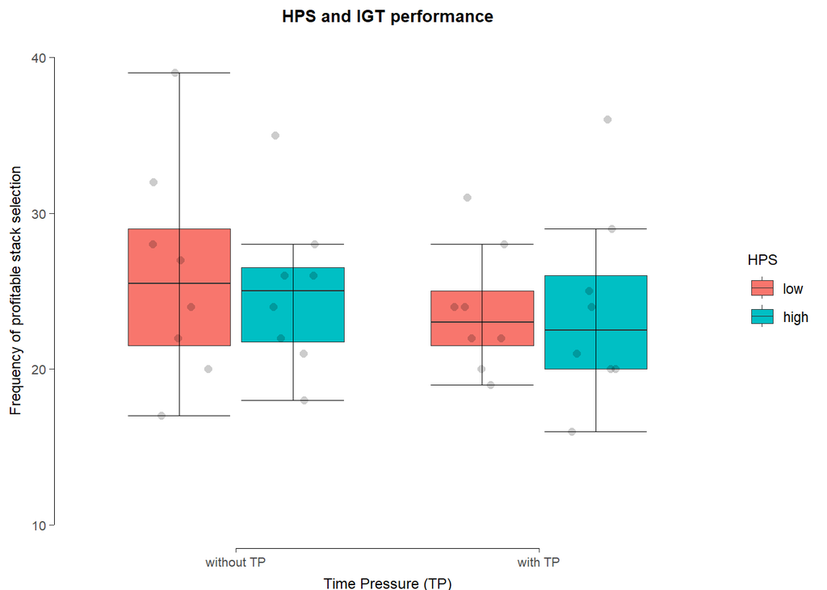

```r
boxpl
```

Interaktionseffekt: Die statistische Analyse legt nahe, dass kein Interaktionseffekt vorhanden ist (kein Zusammenhang, ob hypomane Leute unter time pressure sind oder nicht)

# 8 Weitere Analysen

## 8.1 Wie viele Leute haben sich für/gegen den guten Stapel entschieden und ist das signifikant verschieden von einer Zufallsentscheidung?

Binomialtest:

ohne mid Gruppe

```r
observed_success <- sum(d$sum_good_deck)
total_trials <- nrow(d)*50
expected_probability <- 0.5
expected_success <- expected_probability*total_trials
result <- binom.test(observed_success, total_trials, p = expected_probability)
print(result)
```

```
##
##  Exact binomial test
##
## data:  observed_success and total_trials
## number of successes = 794, number of trials = 1650, p-value = 0.1331
## alternative hypothesis: true probability of success is not equal to 0.5
## 95 percent confidence interval:
##  0.4568523 0.5056389
## sample estimates:
## probability of success
##              0.4812121
```

p-value = 0.1331 > 0.05 probability of success = 0.4812121 -> Wie häufig sich die Proband:innen in den HPS-Gruppen high und low für/gegen einen der guten Stapel entscheiden ist nicht signifikant verschieden von einer Zufallsentscheidung.

mit mid Gruppe (alle Proband:innen)

```r
observed_success <- sum(dat$sum_good_deck)
total_trials <- nrow(dat)*50
expected_probability <- 0.5
expected_success <- expected_probability*total_trials
result <- binom.test(observed_success, total_trials, p = expected_probability)
print(result)
```

```
##
##  Exact binomial test
##
## data:  observed_success and total_trials
## number of successes = 1073, number of trials = 2450, p-value =
## 8.834e-10
## alternative hypothesis: true probability of success is not equal to 0.5
## 95 percent confidence interval:
##  0.4181936 0.4578733
## sample estimates:
## probability of success
##              0.4379592
```

p-value = 8.834e-10 < 0.05 probability of success = 0.4379592 -> Wie häufig sich die Proband:innen für/gegen einen der guten Stapel entscheiden ist signifikant verschieden von einer Zufallsentscheidung.

Binomialtest nicht sinnvoll, weil angenommen wird, dass jede Einzelentscheidung zufällig getroffen wird und das Antwortverhalten der Proband:innen über die verschiedenen Trials hinweg nicht absolut zufällig ist. Proband:innen entwickeln Tendenzen zugunsten der profitablen oder unprofitablen Stapel (-> größere Varianz als bei Zufall).

Stattdessen wird ein Ein-Stichproben t-Test gerechnet (prüfen, ob sich die beobachtete Werteverteilung signifikant von dem Erwartungswert 25 unterscheidet (25, weil 50 Trials, bei Zufall 50% gute Stapel, 50% schlechte Stapel).

Philippe: excluding group “mid” - one-sample t-test instead of binomial-test

```r
t.test(d$sum_good_deck, mu = 25, alternative = "two.sided") # we test against 25 instead of 0, because 25 is our null-hypothesis (chance-level) value in this case
```

```
##
##  One Sample t-test
##
## data:  d$sum_good_deck
## t = -0.82599, df = 32, p-value = 0.4149
## alternative hypothesis: true mean is not equal to 25
## 95 percent confidence interval:
##  21.74401 26.37721
## sample estimates:
## mean of x
##  24.06061
```

Philippe: including group “mid” - one-sample t-test instead of binomial-test

```r
t.test(dat$sum_good_deck, mu = 25, alternative = "two.sided") # we test against 25 instead of 0, because 25 is our null-hypothesis (chance-level) value in this case
```

```
##
##  One Sample t-test
##
## data:  dat$sum_good_deck
## t = -2.8602, df = 48, p-value = 0.00625
## alternative hypothesis: true mean is not equal to 25
## 95 percent confidence interval:
##  19.71734 24.07857
## sample estimates:
## mean of x
##  21.89796
```

Philippe: Proband:innenn wählen den gewinnbringenden Stapel nicht häufiger als man per Zufall erwarten würde. (Aber: Proband:innen scheinen auch nicht wirklich “Zufallsentscheidungen” zu treffen. Das erkennt man z.B. in einer Simulation, in der 49 Proband:innen 50 x zufällig ziehen. Die profitablen Entscheidungen variieren dann sehr viel weniger um den Erwartungswert 25 als im tatsächlichen Sample. Heißt: Die realen Proband:innen tendieren dazu, sich auf den profitablen oder nicht profitablen Stapel zu fixieren. Die Entscheidungen scheinen aber schlussendlich nicht systematisch zugunsten des langfristigen Gewinns getroffen zu werden).

Philippe: so sähe die Simulation z.B. aus:

```r
set.seed(1234) # set random number seed to make results reproducible
npermutations = 10000 # set number of simulations
nparticipants = nrow(dat) # set number of participants
ntrials = 50 # set number of trials
profitChoices_mean = c() # create empty vector for mean profit choices
profitChoices_sd = c() # create empty vector for mean profit choices
for (i in 1:npermutations) {
  profitChoices = c()
  for (j in 1:nparticipants) { profitChoices = c(profitChoices,sum(sample(x = c(0,1), size = ntrials, replace = TRUE))) }
  profitChoices_mean = c(profitChoices_mean, mean(profitChoices))
  profitChoices_sd = c(profitChoices_sd, sd(profitChoices))
}

message('\n=== Means ===')
```

```
##
## === Means ===
```

```r
message(sprintf("Expected count of profitable choices across all simulated datasets: %0.5f", mean(profitChoices_mean))) # should be close to 25
```

```
## Expected count of profitable choices across all simulated datasets: 24.99616
```

```r
message(sprintf("Lower and upper bounds of two-tailed 95%% confidence interval: %0.5f - %0.5f", quantile(profitChoices_mean,0.025), quantile(profitChoices_mean,0.975)))
```

```
## Lower and upper bounds of two-tailed 95% confidence interval: 24.02041 - 25.97959
```

```r
message(sprintf("Observed count of profitable choices: %0.5f", mean(dat$sum_good_deck)))
```

```
## Observed count of profitable choices: 21.89796
```

```r
message(sprintf("Two-tailed p-value for observed count of profitable choices: %0.5f", sum(abs(profitChoices_mean - 25) > abs(mean(dat$sum_good_deck) - 25))/npermutations)) # p-value is < 0.0001 (lowest possibile p-value = 1/npermutations)
```

```
## Two-tailed p-value for observed count of profitable choices: 0.00000
```

```r
message('\n=== Variances ===')
```

```
##
## === Variances ===
```

```r
message(sprintf("Expected SD of profitable choices across all simulated datasets: %0.5f", mean(profitChoices_sd))) # should be close to 25
```

```
## Expected SD of profitable choices across all simulated datasets: 3.51454
```

```r
message(sprintf("Lower and upper bounds of two-tailed 95%% confidence interval: %0.5f - %0.5f", quantile(profitChoices_sd,0.025), quantile(profitChoices_sd,0.975)))
```

```
## Lower and upper bounds of two-tailed 95% confidence interval: 2.84804 - 4.21087
```

```r
message(sprintf("Observed SD of profitable choices: %0.5f", sd(dat$sum_good_deck)))
```

```
## Observed SD of profitable choices: 7.59179
```

```r
message(sprintf("One-tailed p-value for observed SD of profitable choices: %0.5f", sum((profitChoices_sd > sd(dat$sum_good_deck))/npermutations))) # p-value is < 0.0001 (lowest possibile p-value = 1/npermutations)
```

```
## One-tailed p-value for observed SD of profitable choices: 0.00000
```

Die Varianzen (SDs) sind verschiedenen, d.h. die realen Entscheidungen der Proband:innen variieren sehr viel stärker um den Erwartungswert 25 als bei absoluten Zufallsentscheidungen. Legt man die geringeren Varianzen bei absoluten Zufallsentscheidungen einem Signifikanztest zugrunde, unterscheiden sich die beobachteten Mittelwerte hinsichtlich des Signifikanzniveaus sehr deutlich vom erwarteten Wert 25. Genau das passiert beim Binomialtest. Beim t-test werden die größeren beobachteten Varianzen aus der Stichprobe verwendet und gegen 25 getestet. Aufgrund der größeren (realistischeren) Varianzen unterscheiden sich die erreichten Mittelwerte hinsichtlich des Signifikanzniveaus weniger stark von 25. Mit dem t-Test lässt sich also gut die Frage beantworten: “Haben die Proband:innen ihre Entscheidungen zugunsten des langfristig profitablen bzw. unprofitablen Stapels getroffen?”. Berücksichtigt wird dabei auch das strategische Vorgehen der Proband:innenen (äußert sich in größeren Varianzen). Wenn man diese Frage mit dem Binomialtest beantworten würde, dann würde man das unter der Annahme tun, dass die Proband:innen kein strategisches Vorgehen während der Bearbeitung der Aufgabe entwickeln. Die Tests zeigen also zwei Dinge: Die Proband:innen scheinen sich im Schnitt für den langfristig unprofitablen Stapel zu entscheiden (t-test: p = 0.006). Die Proband:innen treffen keine absoluten Zufallensentscheidungen, d.h. sie entwickeln entweder eine Präferenz für den langfristig profitablen oder unprofitablen Stapel (Sample zeigt größere Varianzen um den Erwartungswert 25 (Simulation: p < 0.0001). Der erste Feststellung (Entscheidung für den unprofitablen Stapel) ist sicherlich die interessantere Erkenntnis.

## 8.2 Korrelation Alter mit HPS Scores

```r
cor.test(dat$age,dat$hps_mean)
```

```
##
##  Pearson's product-moment correlation
##
## data:  dat$age and dat$hps_mean
## t = -2.7545, df = 47, p-value = 0.008333
## alternative hypothesis: true correlation is not equal to 0
## 95 percent confidence interval:
##  -0.5919604 -0.1023570
## sample estimates:
##        cor
## -0.3728229
```